# tutorial_garda_meshio

This tutorial is part of [FEMlium](http://femlium.github.io/).

[figure not shown]

```python
import os
import urllib
```

```python
import folium
import matplotlib.pyplot as plt
import meshio
import numpy as np
import pyproj
```

```python
import femlium
```

Auxiliary function to get a `folium` `Map` close to Lake Garda.

```python
def get_garda_geo_map(boundary_icons: bool = False) -> folium.Map:
    """Get a map close to Lake Garda, and possibly add some boundary markers."""
    # Add map close to Lake Garda
    geo_map = folium.Map(location=[45.6389113, 10.7521368], zoom_start=10.3)

    # Add markers
    if boundary_icons:
        location_markers = {
            "Sarca": [45.87395405, 10.87087005],
            "Mincio": [45.43259035, 10.7007715]
        }
        location_colors = {
            "Sarca": "red",
            "Mincio": "green"
        }

        for key in location_markers.keys():
            folium.Marker(
                location=location_markers[key],
                tooltip=key,
                icon=folium.Icon(color=location_colors[key])
            ).add_to(geo_map)

    # Return folium map
    return geo_map
```

```python
get_garda_geo_map()
```

Make this Notebook Trusted to load map: File -> Trust Notebook

[interactive chart not shown]

Read the mesh from file with `meshio`.

```python
msh_filename = "data/garda.msh"
if not os.path.isfile(msh_filename):
    os.makedirs("data", exist_ok=True)
    msh_url = (
        "https://raw.githubusercontent.com/FEMlium/FEMlium/main/"
        "tutorials/01_introduction/data/garda.msh")
    with urllib.request.urlopen(msh_url) as response, open(msh_filename, "wb") as msh_file:
        msh_file.write(response.read())
```

```python
mesh = meshio.read("data/garda.msh")
```

Plot the mesh using `matplotlib`.

```
(np.float64(616658.039149),
 np.float64(647061.960851),
 np.float64(5029877.225841),
 np.float64(5085382.774159))
```

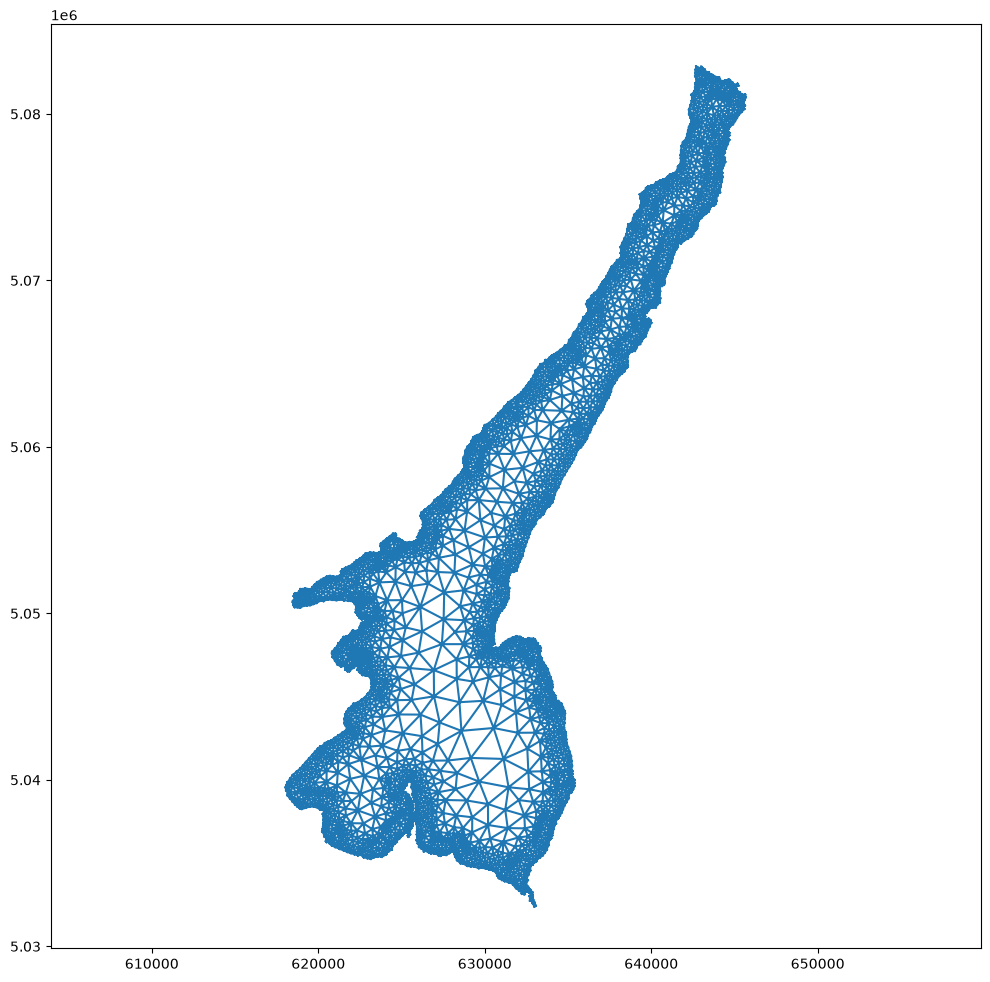

```python
fig = plt.figure(figsize=(12, 12))
fig.gca().triplot(mesh.points[:, 0], mesh.points[:, 1], mesh.cells_dict["triangle"])
fig.gca().axis("equal")
```

Define a `pyproj` `Transformer` to map between different reference systems, because the points read from file are stored a $(x, y)$ pairs in the EPSG32632 reference system, while the map produced by `folium` is based on (latitude, longitude) pairs in the EPSG4326 reference system.

```python
transformer = pyproj.Transformer.from_crs("epsg:32632", "epsg:4326", always_xy=True)
```

We define a mesh plotter for meshes in `meshio` format, which is implemented in `femlium.MeshioPlotter`.

```python
mesh_plotter = femlium.MeshioPlotter(transformer)
```

We use the `mesh_plotter` to draw the mesh on top of the geographic map.

```python
geo_map = get_garda_geo_map()
mesh_plotter.add_mesh_to(geo_map, mesh)
geo_map
```

Make this Notebook Trusted to load map: File -> Trust Notebook

[interactive chart not shown]

We may change the color and the weight of the line.

```python
geo_map = get_garda_geo_map()
mesh_plotter.add_mesh_to(geo_map, mesh, face_colors="red", face_weights=2)
geo_map
```

Make this Notebook Trusted to load map: File -> Trust Notebook

[interactive chart not shown]

Furthermore, we may set the colors and the weights of the face representation to depend on the markers associated to each segment.

```python
geo_map = get_garda_geo_map(boundary_icons=True)
face_colors = {
    0: "gray",
    1: "blue",
    2: "red",
    3: "green"
}
face_weights = {
    0: 1,
    1: 2,
    2: 5,
    3: 5
}
mesh_plotter.add_mesh_to(geo_map, mesh, face_colors=face_colors, face_weights=face_weights)
geo_map
```

Make this Notebook Trusted to load map: File -> Trust Notebook

[interactive chart not shown]

Cells can be colored as well, with a uniform color or depending on the cell markers. We start from a uniform color.

```python
geo_map = get_garda_geo_map()
mesh_plotter.add_mesh_to(geo_map, mesh, cell_colors="orange")
geo_map
```

Make this Notebook Trusted to load map: File -> Trust Notebook

[interactive chart not shown]

We also show the case of colors being set from cell markers. There are two cell markers in this mesh, equal to 1 for the region close to the shoreline (colored in purple) and 2 for the rest of the domain (colored in yellow).

```python
geo_map = get_garda_geo_map()
cell_colors = {
    1: "purple",
    2: "yellow"
}
mesh_plotter.add_mesh_to(geo_map, mesh, cell_colors=cell_colors)
geo_map
```

Make this Notebook Trusted to load map: File -> Trust Notebook

[interactive chart not shown]

Once can use colors associated to both cell and face markers on the same plot.

```python
geo_map = get_garda_geo_map(boundary_icons=True)
mesh_plotter.add_mesh_to(
    geo_map, mesh, cell_colors=cell_colors, face_colors=face_colors, face_weights=face_weights)
geo_map
```

Make this Notebook Trusted to load map: File -> Trust Notebook

[interactive chart not shown]

In order to define a simple scalar field, we compute the centroid of the domain.

```python
centroid = np.mean(mesh.points[:, 0:2], axis=0)
```

We may plot the centroid on top of the mesh.

```python
geo_map = get_garda_geo_map()
mesh_plotter.add_mesh_to(geo_map, mesh)
folium.Marker(location=transformer.transform(*centroid)[::-1], tooltip="Centroid").add_to(geo_map)
geo_map
```

Make this Notebook Trusted to load map: File -> Trust Notebook

[interactive chart not shown]

We define polar coordinates centered at the centroid.

```python
rho = np.sqrt((mesh.points[:, 0] - centroid[0])**2 + (mesh.points[:, 1] - centroid[1])**2)
theta = np.arctan2(mesh.points[:, 1] - centroid[1], mesh.points[:, 0] - centroid[0])
```

The scalar field is defined as $s(\rho, \theta) = \frac{\rho}{\sqrt{1 - 0.5 \cos^2 \theta}}$.

```python
scalar_field = rho / np.sqrt(1 - 0.5 * np.cos(theta)**2)
```

We next show a filled contour plot with 15 levels using `matplotlib`.

```
(np.float64(618040.03559),
 np.float64(645679.96441),
 np.float64(5032400.20531),
 np.float64(5082859.79469))
```

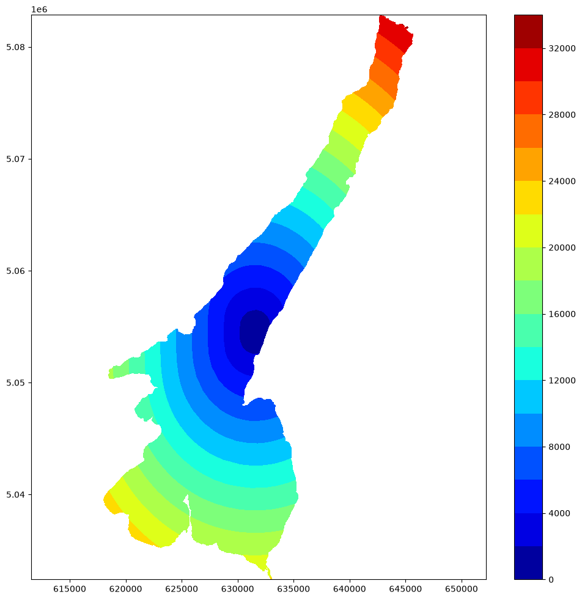

```python
fig = plt.figure(figsize=(12, 12))
trif = fig.gca().tricontourf(
    mesh.points[:, 0], mesh.points[:, 1], mesh.cells_dict["triangle"], scalar_field, levels=15, cmap="jet")
fig.colorbar(trif)
fig.gca().axis("equal")
```

In order to plot a field on a geographic map, we use a `femlium.NumpyPlotter`.

```python
solution_plotter = femlium.NumpyPlotter(transformer)
```

We plot the same filled contour plot on the geographic map.

```python
geo_map = get_garda_geo_map()
solution_plotter.add_scalar_field_to(
    geo_map, mesh.points[:, 0:2], mesh.cells_dict["triangle"], scalar_field,
    mode="contourf", levels=15, cmap="jet")
geo_map
```

Make this Notebook Trusted to load map: File -> Trust Notebook

[interactive chart not shown]

If the optional arguments are not provided then the `contourf` mode will be used, with 10 levels and `jet` colormap.

```python
geo_map = get_garda_geo_map()
solution_plotter.add_scalar_field_to(
    geo_map, mesh.points[:, 0:2], mesh.cells_dict["triangle"], scalar_field)
geo_map
```

Make this Notebook Trusted to load map: File -> Trust Notebook

[interactive chart not shown]

Instead of using an integer `levels` input to generate an equispaced array of levels between the minimum and the maximum of the scalar field, the user may pass levels as a `numpy` array.

```python
geo_map = get_garda_geo_map()
solution_plotter.add_scalar_field_to(
    geo_map, mesh.points[:, 0:2], mesh.cells_dict["triangle"], scalar_field,
    mode="contourf", levels=np.linspace(scalar_field.min(), scalar_field.max(), 15), cmap="jet")
geo_map
```

Make this Notebook Trusted to load map: File -> Trust Notebook

[interactive chart not shown]

`levels` may also be passed in as a list of numbers, rather than a `numpy` array.

```python
geo_map = get_garda_geo_map()
solution_plotter.add_scalar_field_to(
    geo_map, mesh.points[:, 0:2], mesh.cells_dict["triangle"], scalar_field,
    mode="contourf", levels=np.linspace(scalar_field.min(), scalar_field.max(), 15).tolist(), cmap="jet")
geo_map
```

Make this Notebook Trusted to load map: File -> Trust Notebook

[interactive chart not shown]

Similarly, we can also use (unfilled) contour plots.

```
(np.float64(618040.03559),
 np.float64(645679.96441),
 np.float64(5032400.20531),
 np.float64(5082859.79469))
```

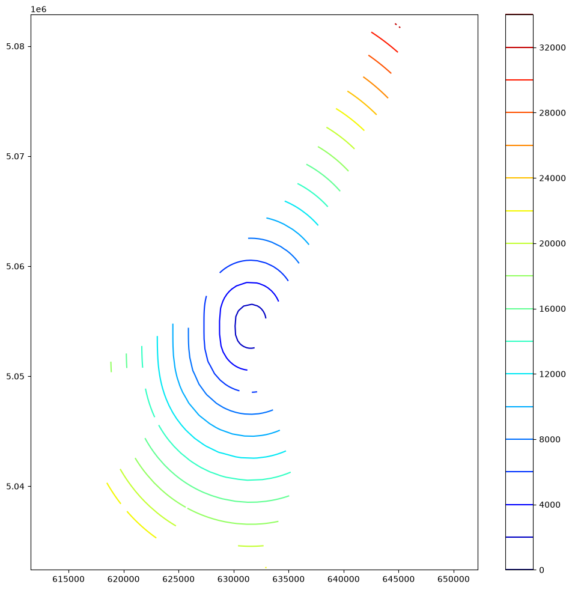

```python
fig = plt.figure(figsize=(12, 12))
tri = fig.gca().tricontour(
    mesh.points[:, 0], mesh.points[:, 1], mesh.cells_dict["triangle"], scalar_field, levels=15, cmap="jet")
fig.colorbar(tri)
fig.gca().axis("equal")
```

```python
geo_map = get_garda_geo_map()
solution_plotter.add_scalar_field_to(
    geo_map, mesh.points[:, 0:2], mesh.cells_dict["triangle"], scalar_field,
    mode="contour", levels=15, cmap="jet")
geo_map
```

Make this Notebook Trusted to load map: File -> Trust Notebook

[interactive chart not shown]

One may also combine mesh plots and solution plots.

```python
geo_map = get_garda_geo_map()
mesh_plotter.add_mesh_to(geo_map, mesh, face_colors="grey")
solution_plotter.add_scalar_field_to(
    geo_map, mesh.points[:, 0:2], mesh.cells_dict["triangle"], scalar_field,
    mode="contour", levels=15, cmap="jet")
geo_map
```

Make this Notebook Trusted to load map: File -> Trust Notebook

[interactive chart not shown]

We next define a vector field $\mathbf{v}(\rho, \theta) = \begin{bmatrix}-\rho \sin \theta\\\rho \cos\theta \end{bmatrix}$.

```python
vector_field = np.array([- rho * np.sin(theta), rho * np.cos(theta)]).T
```

We may obtain contourf plots of the magnitude of the vector field.

```python
geo_map = get_garda_geo_map()
solution_plotter.add_vector_field_to(
    geo_map, mesh.points[:, 0:2], mesh.cells_dict["triangle"], vector_field,
    mode="contourf", levels=15, cmap="jet")
geo_map
```

Make this Notebook Trusted to load map: File -> Trust Notebook

[interactive chart not shown]

If the optional arguments are not provided then the `contourf` mode will be used, with 10 levels and `jet` colormap.

```python
geo_map = get_garda_geo_map()
solution_plotter.add_vector_field_to(
    geo_map, mesh.points[:, 0:2], mesh.cells_dict["triangle"], vector_field)
geo_map
```

Make this Notebook Trusted to load map: File -> Trust Notebook

[interactive chart not shown]

Instead of using an integer `levels` input to generate an equispaced array of levels between the minimum and the maximum of the scalar field, the user may pass levels as a `numpy` array.

```python
geo_map = get_garda_geo_map()
vector_field_magnitude = np.linalg.norm(vector_field, axis=1)
solution_plotter.add_vector_field_to(
    geo_map, mesh.points[:, 0:2], mesh.cells_dict["triangle"], vector_field,
    mode="contourf", levels=np.linspace(vector_field_magnitude.min(), vector_field_magnitude.max(), 15),
    cmap="jet")
geo_map
```

Make this Notebook Trusted to load map: File -> Trust Notebook

[interactive chart not shown]

`levels` may also be passed in as a list of numbers, rather than a `numpy` array.

```python
geo_map = get_garda_geo_map()
solution_plotter.add_vector_field_to(
    geo_map, mesh.points[:, 0:2], mesh.cells_dict["triangle"], vector_field,
    mode="contourf", levels=np.linspace(vector_field_magnitude.min(), vector_field_magnitude.max(), 15).tolist(),
    cmap="jet")
geo_map
```

Make this Notebook Trusted to load map: File -> Trust Notebook

[interactive chart not shown]

The mode can be changed to `contour`.

```python
geo_map = get_garda_geo_map()
solution_plotter.add_vector_field_to(
    geo_map, mesh.points[:, 0:2], mesh.cells_dict["triangle"], vector_field,
    mode="contour", levels=15, cmap="jet")
geo_map
```

Make this Notebook Trusted to load map: File -> Trust Notebook

[interactive chart not shown]

Vector fields can also be plotted using a quiver. We first see the quiver plot in `matplotlib`.

```
(np.float64(616658.039149),
 np.float64(647061.960851),
 np.float64(5029877.225841),
 np.float64(5085382.774159))
```

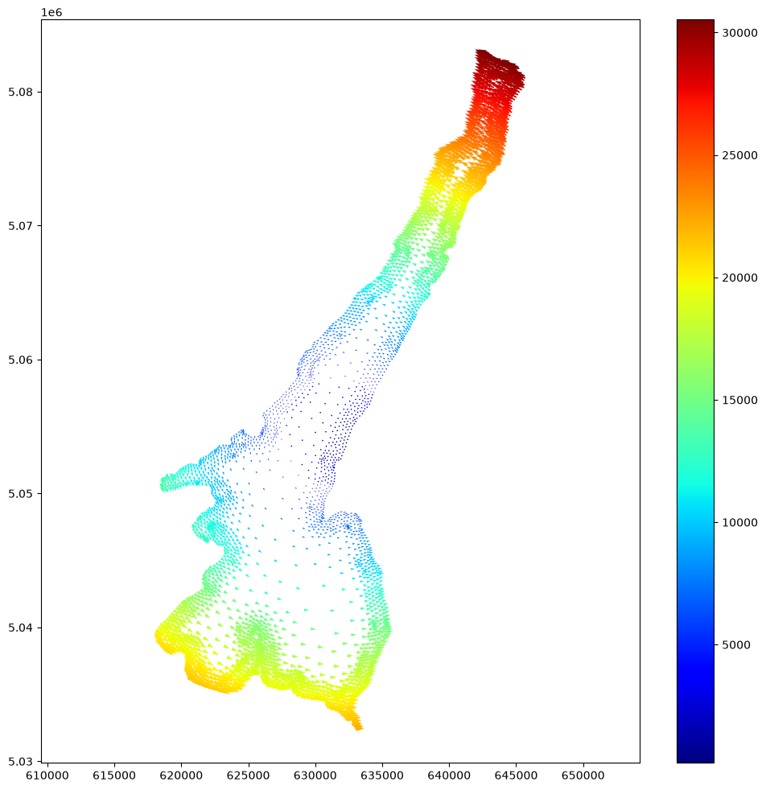

```python
fig = plt.figure(figsize=(12, 12))
quiv = fig.gca().quiver(
    mesh.points[:, 0], mesh.points[:, 1],
    vector_field[:, 0], vector_field[:, 1], np.linalg.norm(vector_field, axis=1),
    cmap="jet")
fig.colorbar(quiv)
fig.gca().axis("equal")
```

A similar plot can rendered on top of the geographic map.

```python
geo_map = get_garda_geo_map()
solution_plotter.add_vector_field_to(
    geo_map, mesh.points[:, 0:2], mesh.cells_dict["triangle"], vector_field,
    mode="quiver", scale=1e-1, cmap="jet")
geo_map
```

Make this Notebook Trusted to load map: File -> Trust Notebook

[interactive chart not shown]